# Figure S5A & S5B — Pancreatic macrophage gene programs scored on the Massier adipose myeloid atlas

## Source & provenance

- **Source script:** `Reviewer3/adipose_data/monocytes_GSE225700_R3_3_15Jan2026.R` (full path: `~/farber-lab/spw13/Pancreas_Project/NatComm_Reply/Reviewer3/adipose_data/monocytes_GSE225700_R3_3_15Jan2026.R`; 4932 lines, the canonical/most-recent version — earlier `…_14Jan2026.R` and `original run/monocytes_GSE225700.R` hold the same core code).
- **Data:** the Massier et al. 2023 adipose **myeloid** Seurat object `my.rds`, derived from the **public GEO dataset GSE225700**. Clusters `myC0–myC15` are Massier’s, not our organ-donor cells, so **no donor PII** is present. (The `GSE225700_RAW.tar → ReadMtx` ingest block at the top of the script is commented-out/dead; the panels read only `my.rds`.)
- **Reproducibility status:** all R chunks are `eval=FALSE` (shown, not executed). The figures are the **already-generated published PDFs** (rendered to PNG for HTML display); nothing is re-run.

## Figure S5A — Large DotPlot of macrophage/myeloid subsets

Per-gene × per-cluster dot plot of the macrophage programs (Fetal-derived signature, Endocytosis, Efferocytosis, Monocyte migration/markers, Lysosome, Lipid metabolism, Pro-inflammatory, Early/Late mitosis) across the 16 `myC` subtypes (incl. `LAM (myC02)`, `DC2 (myC03)`, `classical Mo (myC14)`, `non-classical Mo (myC05)`). **Code from §6 of the script:**

```r
DefaultAssay(my_seurat) <- "RNA"

# Cluster (column) order
my_seurat$Massier_group <- factor(my_seurat$Massier_group, levels = c(
  "M2 (myC0)","M2 (myC01)","M2 (myC04)","M2 (myC13)","M2 (myC09)","M2 (myC08)",
  "M2 (myC12)","M2 (myC11)","M2 (myC07)","MMe (myC10)","LAM (myC02)","Mox (myC15)",
  "M1/M2-like (myC06)","DC2 (myC03)","classical Mo (myC14)","non-classical Mo (myC05)"
))

# Published gene order (rows)
genes_paper <- c(
  "NUSAP1","HIST1H1B","CENPF","PCNA","MCM6",
  "CD58","YWHAH","HTRA1","BHLHE41","C3","CX3CR1",
  "PDPN","OLR1","APOE","CYP27A1","FABP5","LPL","APOC1",
  "NCEH1","CTSD","CD68","ACP5","PSAP","ASAH1","CD63","CTSA","MARCO",
  "LGALS3","LYZ","CD36","EREG","FCN1","VCAN","S100A12",
  "CD44","SELL","CCR2","CCR1","GAS6","AXL","MERTK",
  "CD209","CD163","MRC1","MSR1","MAF","PLTP","SELENOP","LYVE1","STAB1","FOLR2"
)
genes_paper <- genes_paper[genes_paper %in% rownames(my_seurat)]

# 1) Summarised DotPlot data
p_tmp <- DotPlot(my_seurat, features = genes_paper, group.by = "Massier_group", dot.scale = 5)
df <- p_tmp$data
df$id <- factor(df$id, levels = levels(my_seurat$Massier_group))

# 2) Rebuild ggplot: shape-21 filled circles, blue–white–red scaled expression
library(ggplot2)
p_dot_paper_genes <- ggplot(df, aes(x = id, y = features.plot)) +
  geom_point(aes(size = pct.exp, fill = avg.exp.scaled),
             shape = 21, colour = "black", stroke = 0.2) +
  scale_fill_gradient2(low = "#2166ac", mid = "white", high = "#b2182b",
                       midpoint = 0, name = "Scaled\nexpression") +
  scale_size(range = c(0, 6), name = "Fraction\nin group (%)") +
  theme_bw(base_size = 9) +
  theme(panel.grid = element_blank(),
        axis.text.x = element_text(angle = 45, hjust = 1),
        axis.text.y = element_text(face = "bold"), axis.title = element_blank())

ggsave(file.path(plot_dir, "DotPlot_paper_genes_red_blue_blackframe.pdf"),
       plot = p_dot_paper_genes, width = 7, height = 9, dpi = 300)
```

This panel is a **clean 1:1 match**: the `ggsave` filename and mod-date of the on-disk PDF correspond exactly to the published S5A figure. The embedded figure below is that file.

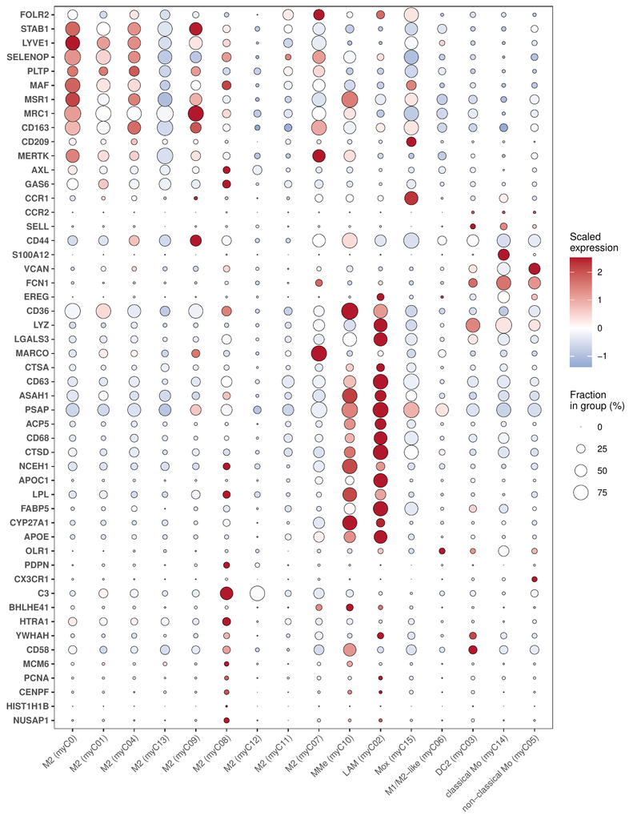

Figure S5A (published): DotPlot_paper_genes_red_blue_blackframe.pdf

## Figure S5B — Module-score heatmap

`AddModuleScore` per macrophage program × myeloid cluster, drawn as a `geom_tile` heatmap. **Code from §7–8 of the script:**

```r
DefaultAssay(my_seurat) <- "RNA"

# 10 program gene sets
gene_groups <- list(
  Fetal_derived_macrophage = c("FOLR2","STAB1","LYVE1","SELENOP","PLTP","MAF","MSR1","MRC1","CD163","CD209"),
  Endocytosis              = c("MERTK","AXL"),
  Efferocytosis            = c("MERTK","AXL","GAS6"),
  Monocyte_Migration       = c("CCR1","CCR2","SELL","CD44"),
  Monocyte_Markers         = c("S100A12","VCAN","FCN1","EREG","CD36","LYZ","LGALS3"),
  Lysosome                 = c("MARCO","CTSA","CD63","ASAH1","PSAP","ACP5","CD68","CTSD","NCEH1"),
  Lipid_Metabolism         = c("APOC1","LPL","FABP5","CYP27A1","APOE","OLR1","PDPN"),
  Pro_inflammatory_tissue_macrophages = c("CX3CR1","C3","BHLHE41","HTRA1","YWHAH","CD58"),
  Late_Mitosis             = c("MCM6","PCNA","CENPF"),
  Early_Mitosis            = c("HIST1H1B","NUSAP1")
)
gene_groups_filt <- lapply(gene_groups, function(g) g[g %in% rownames(my_seurat)])

my_seurat <- AddModuleScore(object = my_seurat, features = gene_groups_filt,
                            name = names(gene_groups_filt), assay = "RNA",
                            nbin = 24, ctrl = 100)

score_cols <- c("Fetal_derived_macrophage1","Endocytosis2","Efferocytosis3","Monocyte_Migration4",
                "Monocyte_Markers5","Lysosome6","Lipid_Metabolism7",
                "Pro_inflammatory_tissue_macrophages8","Late_Mitosis9","Early_Mitosis10")

library(dplyr); library(tidyr); library(ggplot2)
scores_by_cluster <- my_seurat@meta.data %>%
  group_by(Massier_group) %>%
  summarise(across(all_of(score_cols), mean, .names = "{.col}")) %>%
  arrange(Massier_group)
scores_long <- scores_by_cluster %>%
  pivot_longer(cols = all_of(score_cols), names_to = "Module", values_to = "Score")
scores_long$Module <- gsub("[0-9]+$", "", scores_long$Module)

scores_long$Massier_group <- factor(scores_long$Massier_group, levels = c(
  "M2 (myC0)","M2 (myC01)","M2 (myC04)","M2 (myC13)","M2 (myC09)","M2 (myC08)",
  "M2 (myC12)","M2 (myC11)","M2 (myC07)","MMe (myC10)","LAM (myC02)","Mox (myC15)",
  "M1/M2-like (myC06)","DC2 (myC03)","classical Mo (myC14)","non-classical Mo (myC05)"))
scores_long$Module <- factor(scores_long$Module, levels = c(
  "Early_Mitosis","Late_Mitosis","Pro_inflammatory_tissue_macrophages","Lipid_Metabolism",
  "Lysosome","Monocyte_Markers","Monocyte_Migration","Efferocytosis","Endocytosis",
  "Fetal_derived_macrophage"))
scores_long <- dplyr::filter(scores_long, !is.na(Module))

p_module_heatmap <- ggplot(scores_long, aes(x = Massier_group, y = Module, fill = Score)) +
  geom_tile(color = "grey90", linewidth = 0.3) +
  scale_fill_gradient2(low = "#2166ac", mid = "white", high = "#b2182b",
                       midpoint = 0, name = "Module\nscore") +
  theme_bw(base_size = 9) +
  theme(axis.text.x = element_text(angle = 45, hjust = 1),
        axis.title = element_blank(), panel.grid = element_blank())

ggsave(file.path(plot_dir, "ModuleScores_heatmap_CORRECTED.pdf"),
       plot = p_module_heatmap, width = 8, height = 5, dpi = 300)
```

> **Note (Option A — code is illustrative, embedded figure is authoritative):** the heatmap that this script draws/saves has the 10 programs as rows but the **16 `myC` clusters as columns** (`ModuleScores_heatmap_CORRECTED.pdf`, embedded below). The **published S5B uses 3 columns (`Fetal-like`, `LAM`, `Monocytic`)** — a manual collapse of these 16 `myC` clusters into super-groups done **outside this script** (the 3-way grouping `mac_category_3way` exists in the script only for the Wilcoxon tests, never as a 3-column tile heatmap). **No standalone code or PDF for the 3-column version exists on disk;** the 16-column heatmap below is the closest depositable artifact.

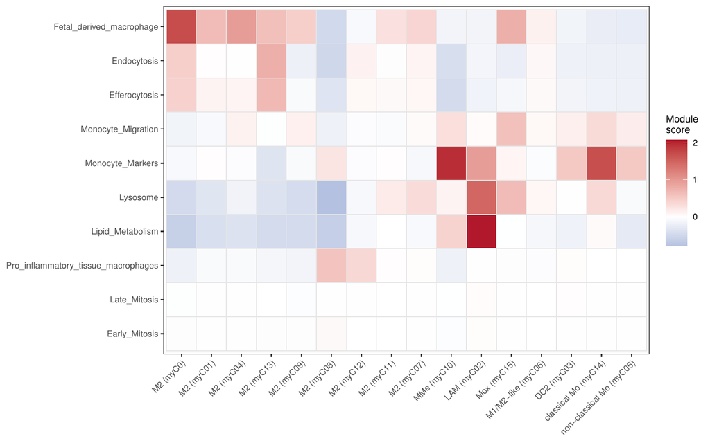

Figure S5B basis (published code/output): ModuleScores_heatmap_CORRECTED.pdf — 10 programs x 16 myC clusters; published panel collapses columns to Fetal-like / LAM / Monocytic